# Homework 6

Tonia Wu

## Tree-Based Models

For this assignment, we will continue working with the file `'pokemon.csv'`, found in `/data`. The file is from Kaggle: https://www.kaggle.com/abcsds/pokemon.

The [Pokémon](https://www.pokemon.com/us/) franchise encompasses video games, TV shows, movies, books, and a card game. This data set was drawn from the video game series and contains statistics about 721 Pokémon, or ‘pocket monsters.’ In Pokémon games, the user plays as a trainer who collects, trades, and battles Pokémon to (a) collect all the Pokémon and (b) become the champion Pokémon trainer.

```r
set.seed = 667
library(tidyverse)
library(tidymodels)
library(ggplot2)
library(yardstick)
library(dplyr)
library(corrplot)
library(corrr)
library(klaR)
library(discrim)
library(poissonreg)
library(pROC)
library(MASS)
library(glmnet)
library(rpart.plot)
library(vip)
library(randomForest)
library(ranger)
library(xgboost)
rawdata <- read.csv('C:\\Users\\me\\Downloads\\homework-5\\homework-5\\data\\Pokemon.csv')
```

### Exercise 1

Read in the data and set things up as in Homework 5:

- Use `clean_names()`

```r
library(janitor)
pokemon <- rawdata %>%
  clean_names()
head(rawdata)
```

```
##   X.                  Name Type.1 Type.2 Total HP Attack Defense Sp..Atk
## 1  1             Bulbasaur  Grass Poison   318 45     49      49      65
## 2  2               Ivysaur  Grass Poison   405 60     62      63      80
## 3  3              Venusaur  Grass Poison   525 80     82      83     100
## 4  3 VenusaurMega Venusaur  Grass Poison   625 80    100     123     122
## 5  4            Charmander   Fire          309 39     52      43      60
## 6  5            Charmeleon   Fire          405 58     64      58      80
##   Sp..Def Speed Generation Legendary
## 1      65    45          1     False
## 2      80    60          1     False
## 3     100    80          1     False
## 4     120    80          1     False
## 5      50    65          1     False
## 6      65    80          1     False
```

- Filter out the rarer Pokémon types

```r
filter_array <- c('Bug', 'Fire', 'Grass', 'Normal', 'Water', 'Psychic')
pokemon1 <- filter(pokemon, type_1 %in% filter_array)
```

- Convert `type_1` and `legendary` to factors

```r
pokemon1$type_1 <- as.factor(pokemon1$type_1)
pokemon1$legendary <- as.factor(pokemon1$legendary)
pokemon1$generation <- as.factor(pokemon1$generation)
```

Do an initial split of the data; you can choose the percentage for splitting. Stratify on the outcome variable.

```r
p_split <- pokemon1 %>%
  initial_split(prop = 0.8, strata = 'type_1')

p_train <- training(p_split)
p_test <- testing(p_split)
```

Fold the training set using *v*-fold cross-validation, with `v = 5`. Stratify on the outcome variable.

```r
p_folded <- vfold_cv(p_train, v = 5, strata = 'type_1')
```

Set up a recipe to predict `type_1` with `legendary`, `generation`, `sp_atk`, `attack`, `speed`, `defense`, `hp`, and `sp_def`:

- Dummy-code `legendary` and `generation`;
- Center and scale all predictors.

```r
p_recipe <- recipe(type_1 ~ legendary + generation
                   + sp_atk + attack + speed
                   + defense + hp + sp_def,
                   data = p_train) %>%
  step_dummy(legendary) %>%
  step_dummy(generation) %>%
  step_normalize(all_predictors())
```

### Exercise 2

Create a correlation matrix of the training set, using the `corrplot` package. *Note: You can choose how to handle the continuous variables for this plot; justify your decision(s).*

> I removed the variable total since it would naturally correlate with the other variables and thus not provide any new information. I also removed the variable x since it represents Pokemon ID and is not valuable information.

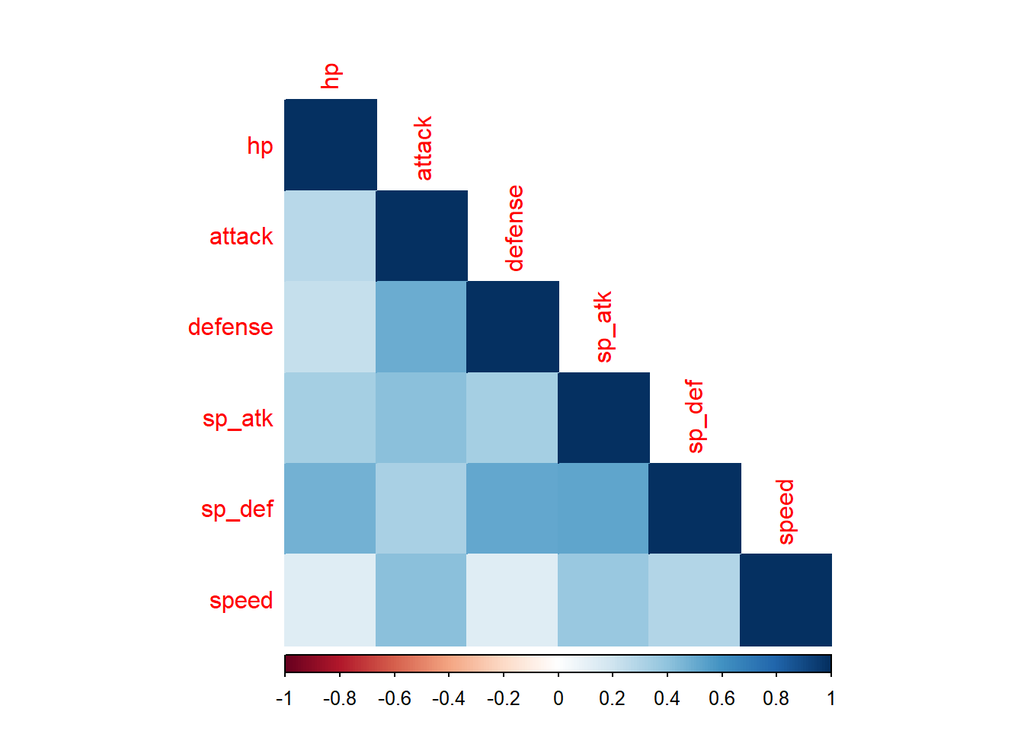

```r
p_train %>%
  dplyr::select(where(is.numeric)) %>%
  dplyr::select(-c(x, total)) %>%
  cor() %>%
  corrplot(method = 'color', type = 'lower')
```

What relationships, if any, do you notice? Do these relationships make sense to you?

> We can see that sp_def and sp_atk are positively correlated with def and atk respectively, and that speed has little to no correlation with hp, def, and sp_def. This could be because a lower speed is often used to balance another higher stat, like we see here with hp and the defense stats.

> It makes sense that no correlations are negative since Pokemon cannot have negative stats.

### Exercise 3

First, set up a decision tree model and workflow. Tune the `cost_complexity` hyperparameter. Use the same levels we used in Lab 7 – that is, `range = c(-3, -1)`. Specify that the metric we want to optimize is `roc_auc`.

```r
tree_spec <- decision_tree() %>%
  set_engine('rpart') %>%
  set_mode('classification') %>%
  set_args(cost_complexity = tune())

p_wkflow <- workflow() %>%
  add_model(tree_spec) %>%
  add_recipe(p_recipe)

p_grid <- grid_regular(cost_complexity(range = c(-3, -1)), levels = 10)

tune <- p_wkflow %>%
  tune_grid(tree_wf,
    resamples = p_folded,
    grid = p_grid,
    metrics = metric_set(roc_auc)
)
```

Print an `autoplot()` of the results. What do you observe? Does a single decision tree perform better with a smaller or larger complexity penalty?

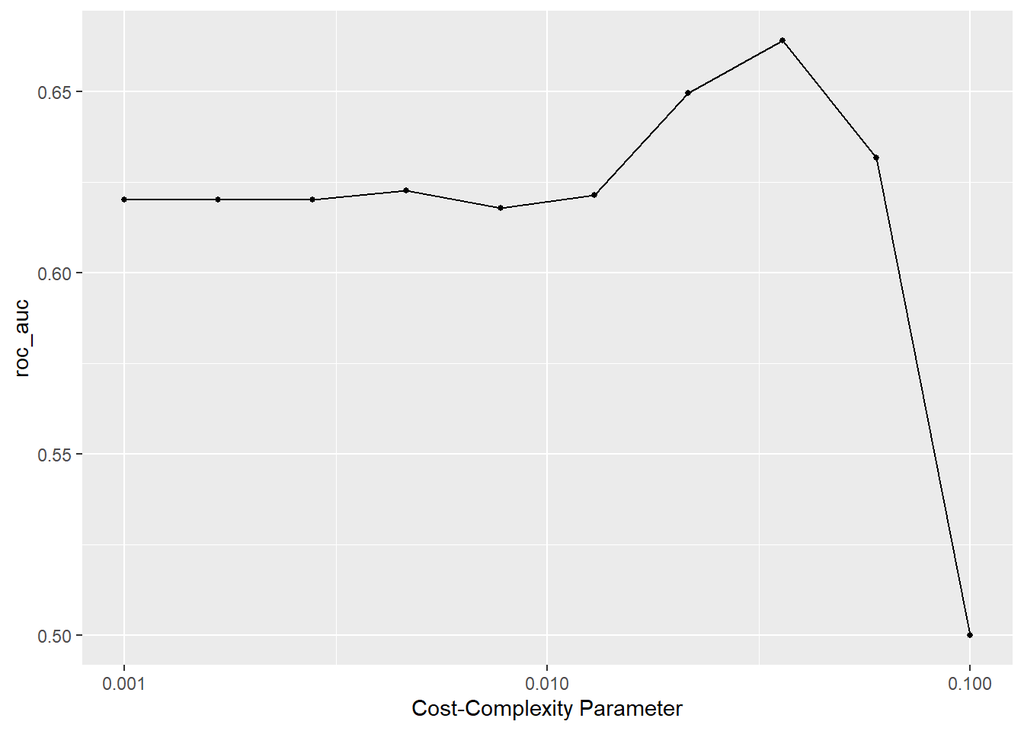

```r
autoplot(tune)
```

### Exercise 4

What is the `roc_auc` of your best-performing pruned decision tree on the folds? *Hint: Use `collect_metrics()` and `arrange()`.*

```r
tune %>%
  collect_metrics() %>%
  arrange(desc(mean)) %>%
  filter(row_number()==1)
```

```
## # A tibble: 1 x 7
##   cost_complexity .metric .estimator  mean     n std_err .config
##             <dbl> <chr>   <chr>      <dbl> <int>   <dbl> <chr>
## 1          0.0359 roc_auc hand_till  0.664     5  0.0134 Preprocessor1_Model08
```

### Exercise 5

Using `rpart.plot`, fit and visualize your best-performing pruned decision tree with the *training* set.

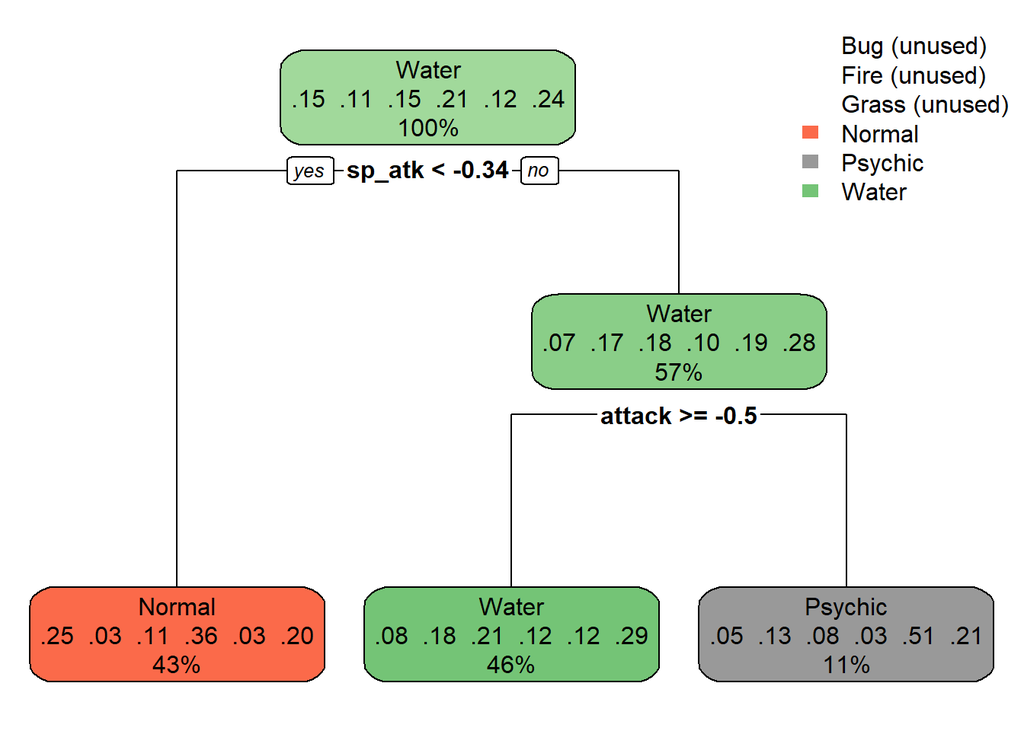

```r
best_tree <- select_best(tune)

final_wkflow <- finalize_workflow(p_wkflow, best_tree)

final_fit <- fit(final_wkflow, data = p_train)

rpart.plot(extract_fit_parsnip(final_fit)$fit)
```

Now set up a random forest model and workflow. Use the `ranger` engine and set `importance = 'impurity'`. Tune `mtry`, `trees`, and `min_n`.

Using the documentation for `rand_forest()`, explain in your own words what each of these hyperparameters represent.

> mtry: the number of randomly sampled predictors at each split of the tree models

> trees: the number of trees created

> min_n: the minimum number of data points in a node required for splitting nodes into leaves

```r
rf_spec <- rand_forest(mtry = tune(), trees = tune(), min_n = tune()) %>%
  set_engine('ranger', importance = 'impurity') %>%
  set_mode('classification')

rf_wkflow <- workflow() %>%
  add_recipe(p_recipe) %>%
  add_model(rf_spec)
```

Create a regular grid with 8 levels each. You can choose plausible ranges for each hyperparameter. Note that `mtry` should not be smaller than 1 or larger than 8. **Explain why not. What type of model would `mtry = 8` represent?**

> From the documentation: mtry is the number of predictors that will be randomly sampled at each split when creating the tree models.

> Thus we cannot set mtry to be more than 8, the number of predictors we have. At mtry = 8 we get the bagging model.

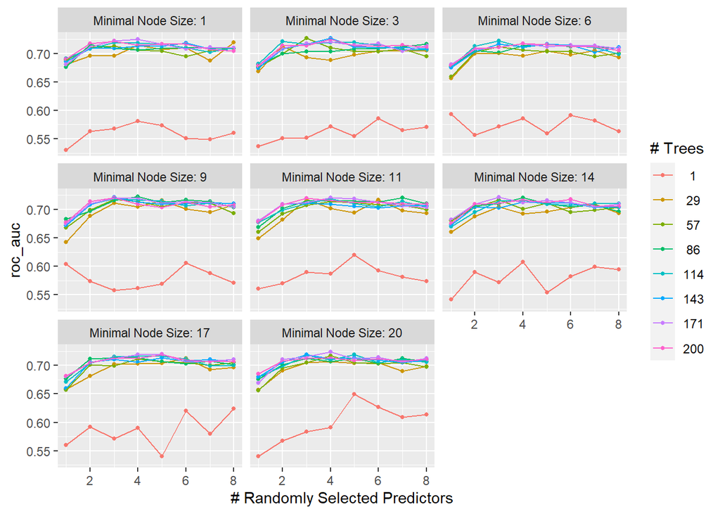

```r
rf_grid <- grid_regular(mtry(range = c(1,8)),
                        trees(range = c(1,200)),
                        min_n(range = c(1, 20)),
                        levels = 8)

rf_tune <- tune_grid(
  rf_wkflow,
  resamples = p_folded,
  grid = rf_grid,
  metrics = metric_set(roc_auc))

autoplot(rf_tune, metric = 'roc_auc')
```

### Exercise 6

Specify `roc_auc` as a metric. Tune the model and print an `autoplot()` of the results. What do you observe? What values of the hyperparameters seem to yield the best performance?

```r
rf_tune <- tune_grid(rf_wkflow,
                     resamples = p_folded,
                     grid = rf_grid,
                     metrics = metric_set(roc_auc))
```

### Exercise 7

What is the `roc_auc` of your best-performing random forest model on the folds? *Hint: Use `collect_metrics()` and `arrange()`.*

```r
rf_tune %>%
  collect_metrics() %>%
  arrange(-mean) %>%
  filter(row_number()==1)
```

```
## # A tibble: 1 x 9
##    mtry trees min_n .metric .estimator  mean     n std_err .config
##   <int> <int> <int> <chr>   <chr>      <dbl> <int>   <dbl> <chr>
## 1     4   200     6 roc_auc hand_till  0.724     5  0.0132 Preprocessor1_Model1~
```

### Exercise 8

Create a variable importance plot, using `vip()`, with your best-performing random forest model fit on the *training* set.

Which variables were most useful? Which were least useful? Are these results what you expected, or not?

> sp_atk, atk, and hp/speed are the most useful; the generations are the least useful. I expected the generations to be this way but had no expectations for the other stats, as I don’t know Pokemon that well. That said I find it interesting hp and speed ranked higher than either of the def stats.

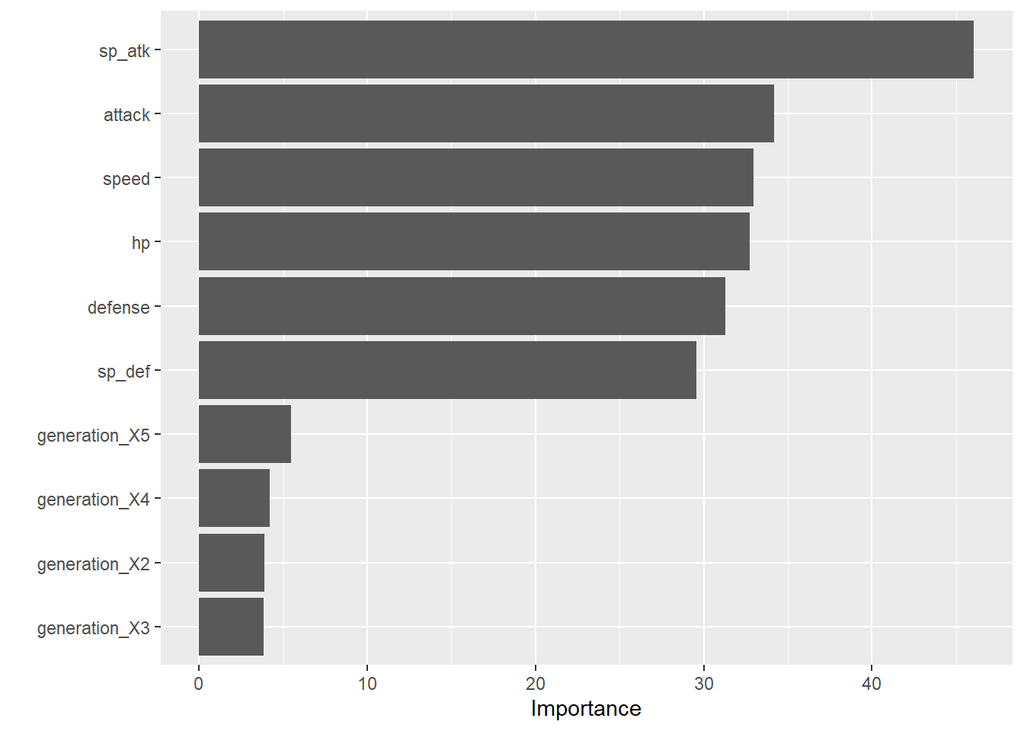

```r
rf_best = rf_tune %>%
  select_best('roc_auc')

final_wkflow <- rf_wkflow %>%
  finalize_workflow(rf_best)

rf_fit <- final_wkflow %>%
  fit(p_train)

rf_fit %>%
  extract_fit_parsnip() %>%
  vip()
```

### Exercise 9

Finally, set up a boosted tree model and workflow. Use the `xgboost` engine. Tune `trees`. Create a regular grid with 10 levels; let `trees` range from 10 to 2000. Specify `roc_auc` and again print an `autoplot()` of the results.

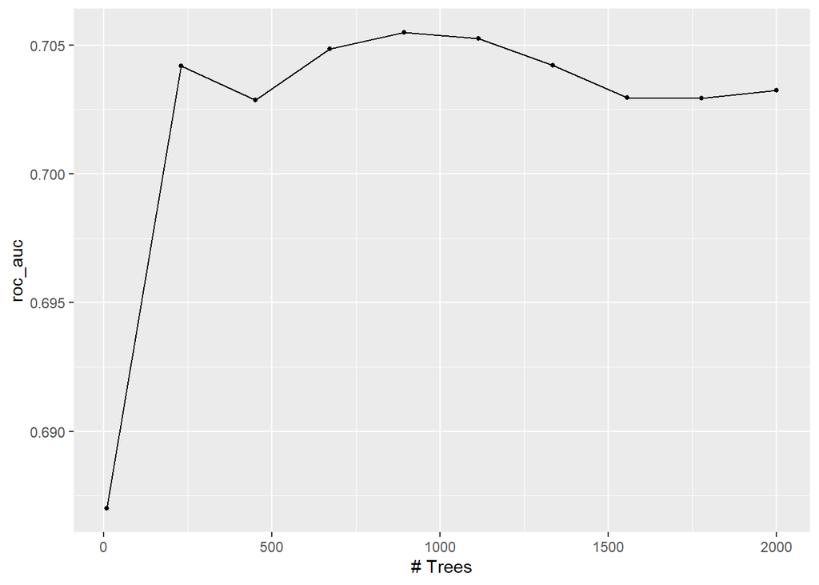

```r
p_boost_spec <- boost_tree() %>%
  set_engine('xgboost') %>%
  set_mode('classification')

p_boost_wkflow <- workflow() %>%
  add_model(p_boost_spec %>%
              set_args(trees = tune())) %>%
  add_recipe(p_recipe)

p_boost_grid <- grid_regular(trees(range = c(10,2000)),
                                   levels = 10)

p_boost_tune_res <- tune_grid(p_boost_wkflow,
                                    resamples = p_folded,
                                    grid = p_boost_grid,
                                    metrics = metric_set(roc_auc))
autoplot(p_boost_tune_res)
```

What is the `roc_auc` of your best-performing boosted tree model on the folds? *Hint: Use `collect_metrics()` and `arrange()`.*

```r
p_boost_tune_res %>%
  collect_metrics() %>%
  arrange(desc(mean)) %>%
  filter(row_number()==1)
```

```
## # A tibble: 1 x 7
##   trees .metric .estimator  mean     n std_err .config
##   <int> <chr>   <chr>      <dbl> <int>   <dbl> <chr>
## 1   894 roc_auc hand_till  0.705     5 0.00721 Preprocessor1_Model05
```

### Exercise 10

Display a table of the three ROC AUC values for your best-performing pruned tree, random forest, and boosted tree models. Which performed best on the folds? Select the best of the three and use `select_best()`, `finalize_workflow()`, and `fit()` to fit it to the *testing* set.

Print the AUC value of your best-performing model on the testing set. Print the ROC curves. Finally, create and visualize a confusion matrix heat map.

Which classes was your model most accurate at predicting? Which was it worst at?

```r
boost_best <- (collect_metrics(p_boost_tune_res) %>%
                 arrange(desc(mean)))[1,c('.metric','mean')]
rf_best <- (collect_metrics(rf_tune) %>%
              arrange(desc(mean)))[1,c('.metric','mean')]
decision_best <- (collect_metrics(tune) %>%
                    arrange(desc(mean)))[1,c('.metric','mean')]

model_types <- c("Decision Tree", "Random Forest", "Boosted Tree")

p_collection <- rbind(rf_best, decision_best, boost_best)

table <- cbind(model_types, p_collection)

table
```

[output not shown]

```r
best_rf <- select_best(rf_tune, metric = 'roc_auc')
rf_final <- finalize_workflow(rf_wkflow, best_rf)
rf_final_fit <- fit(rf_final, data = p_train)

# get auc
roc_auc(augment(rf_final_fit, new_data = p_test), type_1,
        .pred_Bug, .pred_Fire, .pred_Grass, .pred_Normal,
        .pred_Psychic, .pred_Water)
```

```
## # A tibble: 1 x 3
##   .metric .estimator .estimate
##   <chr>   <chr>          <dbl>
## 1 roc_auc hand_till      0.753
```

```r
# get roc for best model
p_roc_best_tree <- augment(rf_final_fit, new_data = p_test) %>%
  roc_auc(truth = type_1,
          estimate = c('.pred_Bug', '.pred_Fire', '.pred_Grass',
                       '.pred_Normal', '.pred_Psychic',
                       '.pred_Water'))

# autoplot(p_roc_best_tree)
# test_curves = roc_curve(data=p_train,
#                         truth=type_1,
#                         estimate=c(.pred_Bug, .pred_Fire, .pred_Grass,
#                                     .pred_Normal, .pred_Psychic, .pred_Water))
# autoplot(test_curves)
```

> Note the autoplot is broken.

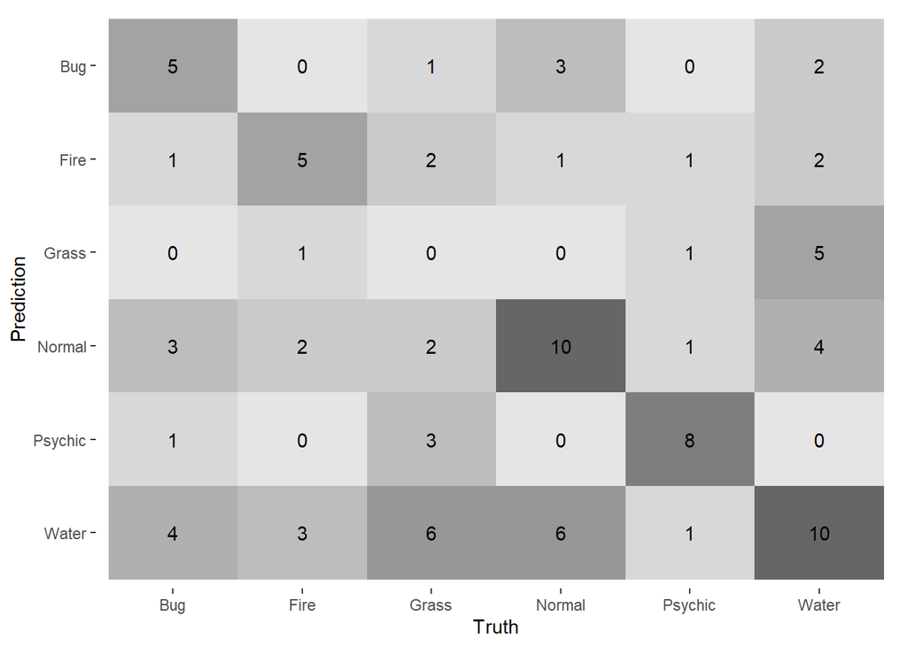

```r
#heat map
augment(rf_final_fit, new_data = p_test) %>%
  conf_mat(truth = type_1, estimate = .pred_class)  %>% autoplot(type = 'heatmap')
```